# Version Control

#### How to Implement Git in your Workflow

First, you need to create a local directory where you will house all your local projects that you will link to GitLab. Below is an example file structure.

[figure not shown]

Then, in GitLab, create a new repository for your project. Always add a README file and gitignore.

Next, you need to get this remote repository to your local environment so you can actually do stuff.

##### Bash Method

In GitLab in a browser window, navigate to the new repository and locate the “Clone” drop down button. Click the copy button next to “Clone with SSH.” Keep this on your clipboard.

[figure not shown]

Right click in your GitLab directory in your Windows File Explorer program. Click on “Git Bash Here” to open a terminal window in your current GitLab directory. Use the following script to clone the remote repository to your local environment.

**Pro Tip: The Ctrl+V paste shortcut doesn’t work in a command prompt. Use Shift+Insert instead to paste the link from your clipboard or right click the line you are editing and select Paste.**

```bash
git clone [link from GitLab]
# Example
#git clone git@gitlab.deq.virginia.gov:deq_water/wqm/testproject.git
```

You were successful if you now have a directory in your GitLab directory named the same as your GitLab repo.

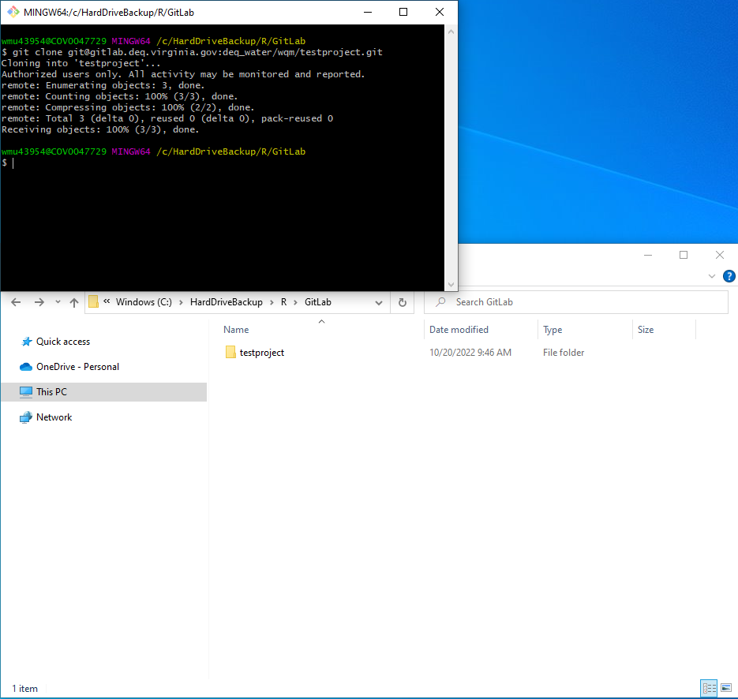

Open the new directory and start working. When you are ready to make your first commit to the remote repository, right click in your Windows File Explorer window and choose “Git Bash Here” to open a command prompt in your current location. Stage updates, commit, push, pull, etc. using the following script examples.

```bash
# Stage all files (not excluded in the gitignore) for commit
git add -A

# Commit all files staged and add a commit message
git commit -a -m 'update readme'

# Push commits to remote repo (main branch)
git push origin main
```

This is not a comprehensive list of all git commands one could or should use. Simple google queries can answer most questions on using bash with Git.